# Hypothesis Testing

Logan Kelly, Ph.D.

Managerial Statistics - ECON 730

## Objectives

- After this lecture you should be able to conduct Hypothesis Tests
- Topics:
  - What is Hypothesis Testing
  - Null and Alternative Hypothesizes
  - Type I and Type II Error
  - Confidence Level, Significance Level, and Power
  - p-values

# 1 Case Background

## 1.1 Three Cases

- Test Marketing
- Gender Gap
- Asset Return

# 2 Hypothsis Testing

## 2.1 Student’s t distributions with various degrees of freedom

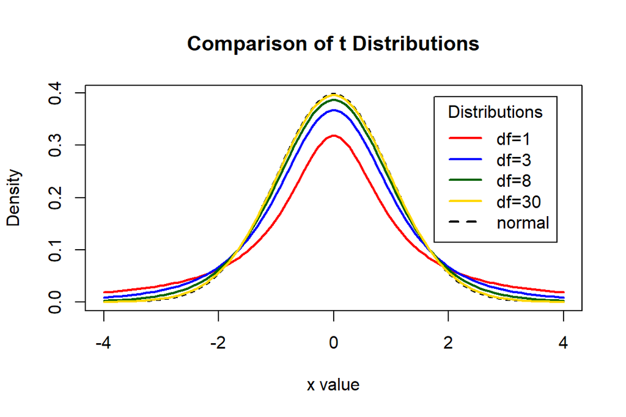

## 2.2 The Two-tailed Test Rejection Region

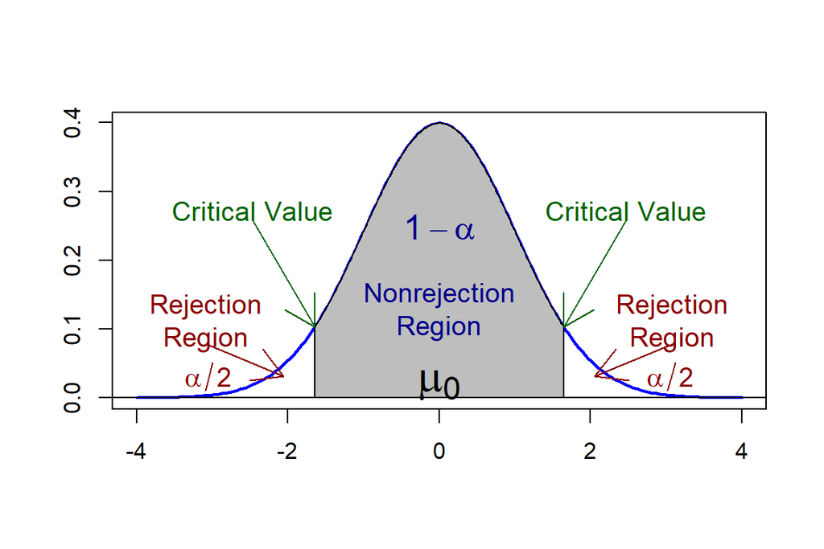

## 2.3 Type 1 and Type 2 Error, and Power in Hypothesis Testing

- **Type 1 error:** *Rejecting* the null hypothesis ($H_0$) when $H_0$ is *true*
  - Significance level ($\alpha$) is the probability of making Type 1 error
  - This value is usually set to 0.05
- **Type 2 error:** *Failing to reject* the null hypothesis ($H_0$) when $H_0$ is *false*
  - The value $\beta$ is the probability of making Type 2 error
- **The Power of a test:** the probability of correctly rejecting $H_0$ when it is false ($1-\beta$)

## 2.4 The wrights and wrongs of a hypothsis test

- $H_0$ is true
  - Fail to reject $H_0$
    - Correct Conclusion
    - Probability = $1-\alpha$ which is called the Confidence Level
  - Reject $H_0$
    - Incorrect Conclusion ~ Type 1 error
    - Probability = $\alpha$ which is called the Significance Level
- $H_0$ is false
  - Fail to reject $H_0$
    - Incorrect Conclusion ~ Type 2 error
    - Probability = $\beta$
  - Reject $H_0$
    - Correct Conclusion
    - Probability = $1-\beta$ which is called the Power of the Test

[interactive chart not shown]

https://rpsychologist.com/d3/nhst/

## 2.5 p-value

- p-value:
  - Assume that $H_0$ is true, then
  - the p-value is it is the probability of getting a statistic as or more in favor of the alternative hypothesis HA
- Low p-values indicate that if $H_0$ is true, we have observed an improbable event
- **NOTE:** Failing to reject $H_0$ does not mean we have gathered evidence in favor of it (i.e., absence of evidence does not imply evidence of absence)

# 3 Case 1: Test Markiting

## 3.1 Case Bankground

- The Pineapple Computer Company is deciding whether or not to introduce a new color option in their flagship laptop computer.
- Adding a new color will only be Profitable if average sales greater than 275 units per week.
- Data: Sales data collected over 36 weeks.

## 3.2 Hypothsis Test

- $H_0$: Average sales is less than 275 per week
- $H_\alpha$: Average sales is greater than 275 per week

## Load the Data

```r
test.market <- read.csv("data/PCC_TestMarket.csv")
```

## Conduct the Test

```r
t.test(test.market$sales,
       mu = 275, alternative = "greater", conf.level = 0.95)
```

```
    One Sample t-test

data:  test.market$sales
t = 1.7575, df = 35, p-value = 0.04379
alternative hypothesis: true mean is greater than 275
95 percent confidence interval:
 275.601     Inf
sample estimates:
mean of x
 290.5495
```

## Graph the Test

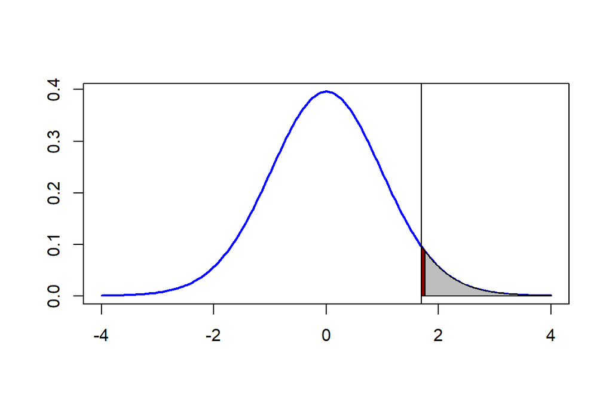

## Zoom in on the tail

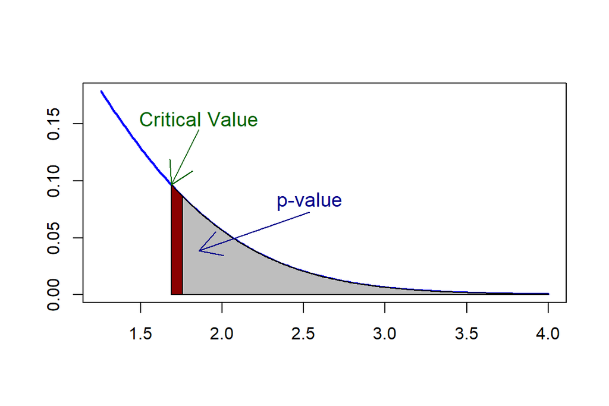

# 4 Case 2: The Office - Sales Data

## 4.2 First look at the data

```r
sales <- read.csv("data/TO_SalesData.csv")
head(sales)
```

```
  order.date  month    rep  region   item units unit.price total.rev
1   1/6/2014 14-Jan Kivell Central Binder    88      18.99   1671.12
2   1/6/2014 14-Jan  Jones    East Pencil    86       2.19    188.34
3   1/6/2014 14-Jan Howard    East Binder    68      21.99   1495.32
4  1/23/2014 14-Jan Kivell Central Binder    55      18.99   1044.45
5  1/23/2014 14-Jan   Gill Central Binder    39      18.99    740.61
6  1/23/2014 14-Jan Parent Central Binder    46      18.99    873.54
```

## 4.3 Sales by Rep

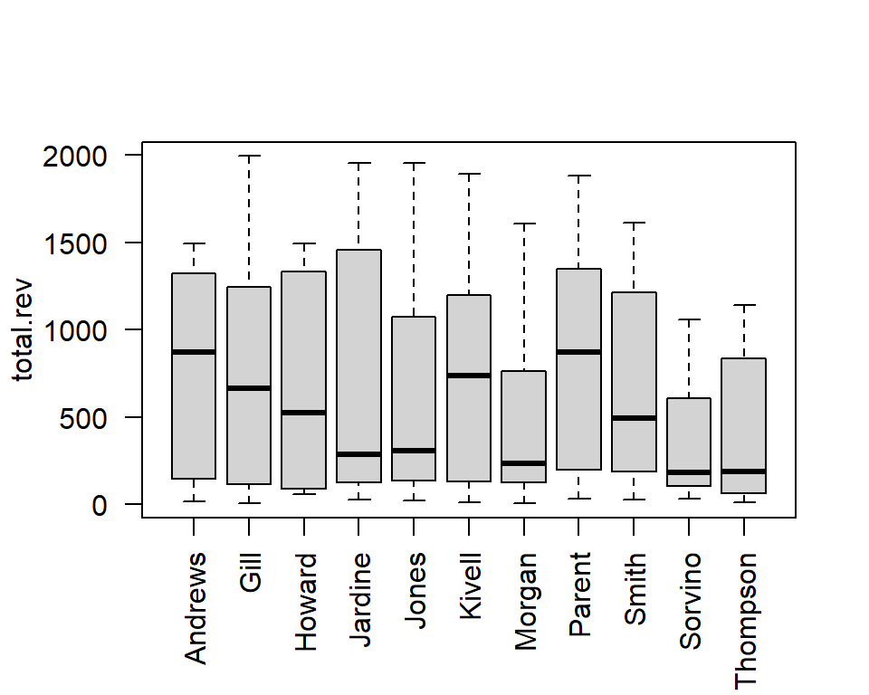

```r
attach(sales)
boxplot(total.rev~rep, las=2, xlab=NULL, outline=FALSE)
```

## 4.4 Sales by Rep

```r
  suppressMessages(library(tidyverse))

  sales.rep.avg <- sales %>% group_by(rep) %>%
    summarize(avg = mean(total.rev))
  sales.rep.avg
```

```
# A tibble: 11 x 2
   rep        avg
   <chr>    <dbl>
 1 Andrews  2162.
 2 Gill     1053.
 3 Howard    680.
 4 Jardine  1134.
 5 Jones    1237.
 6 Kivell    847.
 7 Morgan    678.
 8 Parent   1497.
 9 Smith    1179.
10 Sorvino   346.
11 Thompson 1088.
```

## 4.5 Sales by Rep

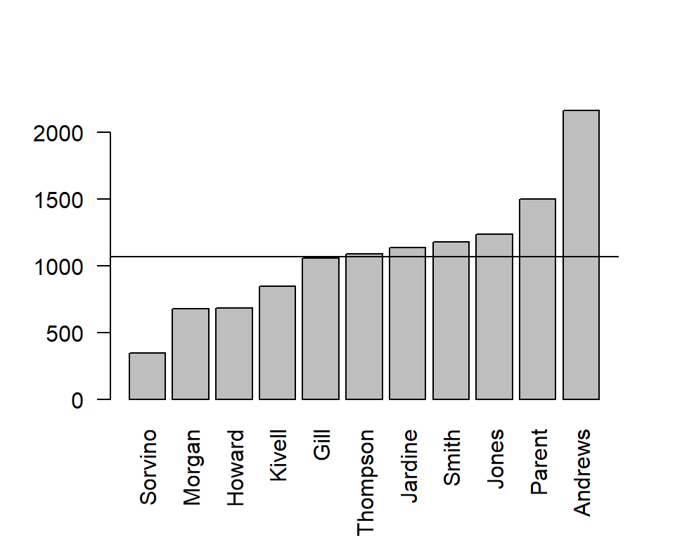

```r
  suppressMessages(library(tidyverse))

  sales.rep.avg <- sales.rep.avg %>% arrange(avg)

  barplot(height=sales.rep.avg$avg, names.arg = sales.rep.avg$rep, las=2)
  abline(h=mean(sales$total.rev))
```

```r
  t.test(sales$total.rev ~ sales$rep=="Sorvino", mu=0,conf=0.95,var.eq=F)
```

```
    Welch Two Sample t-test

data:  sales$total.rev by sales$rep == "Sorvino"
t = 4.3888, df = 190.69, p-value = 1.885e-05
alternative hypothesis: true difference in means is not equal to 0
95 percent confidence interval:
  444.7123 1170.7665
sample estimates:
mean in group FALSE  mean in group TRUE
          1153.5476            345.8082
```